# Electricity Market Prices - July Report

Egecan Esen

8/17/2020

## First Glimpse At the Data

This is a report about the electricity prices in July 2020. The data used in this project can be reached from this [link](https://rapor.epias.com.tr/rapor/xhtml/ptfSmfListeleme.xhtml).

First, let’s take a quick look at the data:

```r
raw_df %>% glimpse()
```

```
## Rows: 744
## Columns: 6
## $ Tarih                                 <chr> "01.07.20 00:00", "01.07.20 01:…
## $ PTF                                   <chr> "323,85", "326,95", "324,31", "…
## $ SMF                                   <chr> "211,00", "201,00", "211,00", "…
## $ `Pozitif Dengesizlik Fiyatı (TL/MWh)` <chr> "204,67", "194,97", "204,67", "…
## $ `Negatif Dengesizlik Fiyatı (TL/MWh)` <chr> "333,57", "336,76", "334,04", "…
## $ `SMF Yön`                             <chr> "↓Enerji Fazlası", "↓Enerji Faz…
```

## Rearranging the Dataframe

It can be seen that all the data is in form of ‘character’. The name of the columns must be changed, ‘Tarih’ column needs to be converted to ‘POSIXct’, ‘PTF’ & ‘SMF’ need to be converted to ‘double’.

```r
df <- raw_df
df$DateTime <- dmy_hm(df$Tarih)

df[,c(2:4)] <- lapply(df[,c(2:4)],function(x) as.numeric(gsub(",", ".", gsub("\\.", "", x))))

colnames(df)[2] = "MCP" #Market Clearing Price
colnames(df)[3] = "SMP" #System Marginal Price

df <- df %>% select(7,2,3)

df %>% glimpse()
```

```
## Rows: 744
## Columns: 3
## $ DateTime <dttm> 2020-07-01 00:00:00, 2020-07-01 01:00:00, 2020-07-01 02:00:…
## $ MCP      <dbl> 323.85, 326.95, 324.31, 322.11, 320.00, 286.21, 210.13, 318.…
## $ SMP      <dbl> 211.00, 201.00, 211.00, 211.00, 201.00, 181.00, 113.75, 201.…
```

The Dataframe is ready to analyze.

## Data Analysis

The visualization of the dataframe:

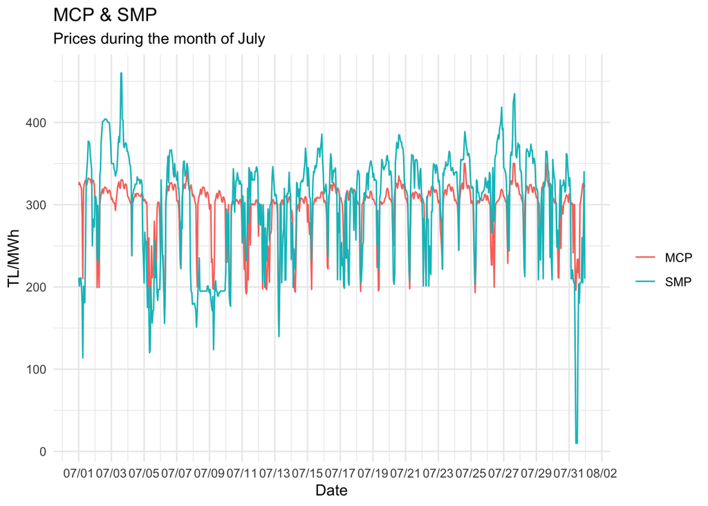

```r
df %>% pivot_longer(.,-DateTime) %>% ggplot(aes(x=DateTime,y=value,color=name)) +geom_line() + theme_minimal() + labs(x="Date", y="TL/MWh", color="", title = "MCP & SMP", subtitle = "Prices during the month of July") + scale_x_datetime(date_breaks = "2 days",date_labels = "%m/%d")
```

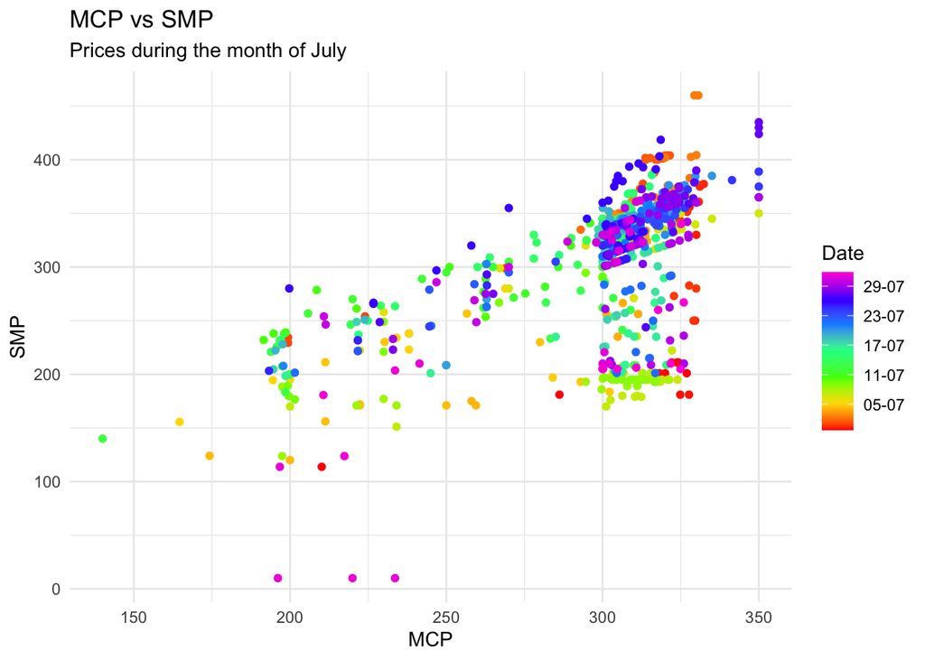

```r
df %>% ggplot(aes(x=MCP,y=SMP, color=DateTime)) +geom_point(position="jitter") + theme_minimal() + labs(title = "MCP vs SMP", subtitle = "Prices during the month of July") + scale_colour_gradientn(name= "Date", colours=rainbow(7), labels= c("30-06","05-07","11-07","17-07","23-07","29-07"))
```

Let’s check some basic daily stats of market clearing and system marginal prices:

```r
#Mean, Median, Maximum, Minimum & Standard Deviation of Each Day's MCP
MCP <- df %>%
  mutate(Day=date(DateTime)) %>%
  group_by(Day) %>%
  summarise(meanMCP = mean(MCP), medianMCP = median(MCP), maxMCP = max(MCP), minMCP = min(MCP), sdMCP =sd(MCP))

#Mean, Median, Maximum, Minimum & Standard Deviation of Each Day's SMP
SMP <- df %>%
  mutate(Day=date(DateTime)) %>%
  group_by(Day) %>%
  summarise(meanSMP = mean(SMP), medianSMP = median(SMP), maxSMP = max(SMP), minSMP = min(SMP), sdSMP = sd(SMP))

Means <- bind_cols(Day = MCP$Day,meanMCP = MCP$meanMCP, meanSMP = SMP$meanSMP)
```

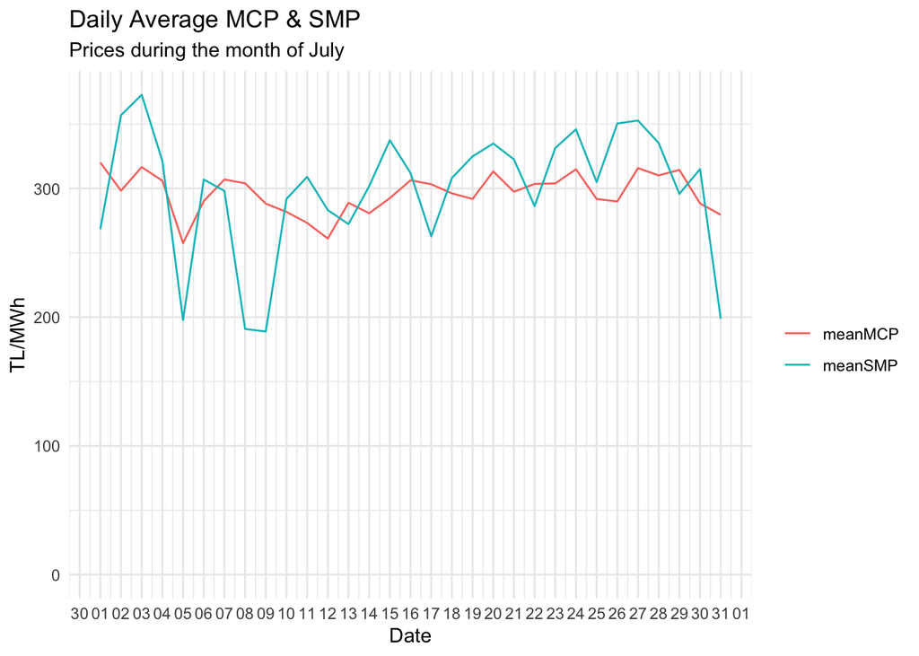

```r
Means %>% pivot_longer(.,-Day) %>% ggplot(aes(x=Day,y=value,color=name)) +geom_line() + theme_minimal() + labs(x="Date", y="TL/MWh", color="", title = "Daily Average MCP & SMP ", subtitle = "Prices during the month of July") + expand_limits(y=0) + scale_x_date(date_breaks = "1 day", date_labels = "%d")
```

The statistics of hourly prices can be checked in the same way:

```r
df %>%
  mutate(Hour=hour(DateTime)) %>%
  group_by(Hour) %>%
  summarise(meanMCP = mean(MCP), medianMCP = median(MCP), maxMCP = max(MCP), minMCP = min(MCP), sdMCP =sd(MCP))
```

```
## # A tibble: 24 x 6
##     Hour meanMCP medianMCP maxMCP minMCP sdMCP
##    <int>   <dbl>     <dbl>  <dbl>  <dbl> <dbl>
##  1     0    297.      305.   324.   230. 22.0
##  2     1    306.      306.   327.   293   5.88
##  3     2    298.      304.   324.   230. 17.4
##  4     3    284.      301.   322.   199. 32.7
##  5     4    285.      300    320    219. 24.6
##  6     5    247.      245.   302.   196. 35.3
##  7     6    213.      202.   293    140. 29.0
##  8     7    269.      286.   318.   194. 39.3
##  9     8    295.      304.   325.   195. 32.6
## 10     9    288.      311.   328.   174. 47.0
## # … with 14 more rows
```

```r
df %>%
  mutate(Hour=hour(DateTime)) %>%
  group_by(Hour) %>%
  summarise(meanSMP = mean(SMP), medianSMP = median(SMP), maxSMP = max(SMP), minSMP = min(SMP), sdSMP = sd(SMP))
```

```
## # A tibble: 24 x 6
##     Hour meanSMP medianSMP maxSMP minSMP sdSMP
##    <int>   <dbl>     <dbl>  <dbl>  <dbl> <dbl>
##  1     0    294.      317.   365    179   55.0
##  2     1    308.      320.   361.   180   46.6
##  3     2    297.      315.   357.   180   49.2
##  4     3    283.      301.   350    176   55.1
##  5     4    280.      299.   347.   170   49.9
##  6     5    248.      250.   341.   151.  49.8
##  7     6    213.      221.   335.   114.  43.1
##  8     7    260.      269    340.   171   55.5
##  9     8    278.      301    345    120   59.2
## 10     9    291.      320.   378.   114.  69.7
## # … with 14 more rows
```

From the tables above, it seems that the prices are lower during night time. Below is the comparison of the prices during day (8-22) and night (22-8):

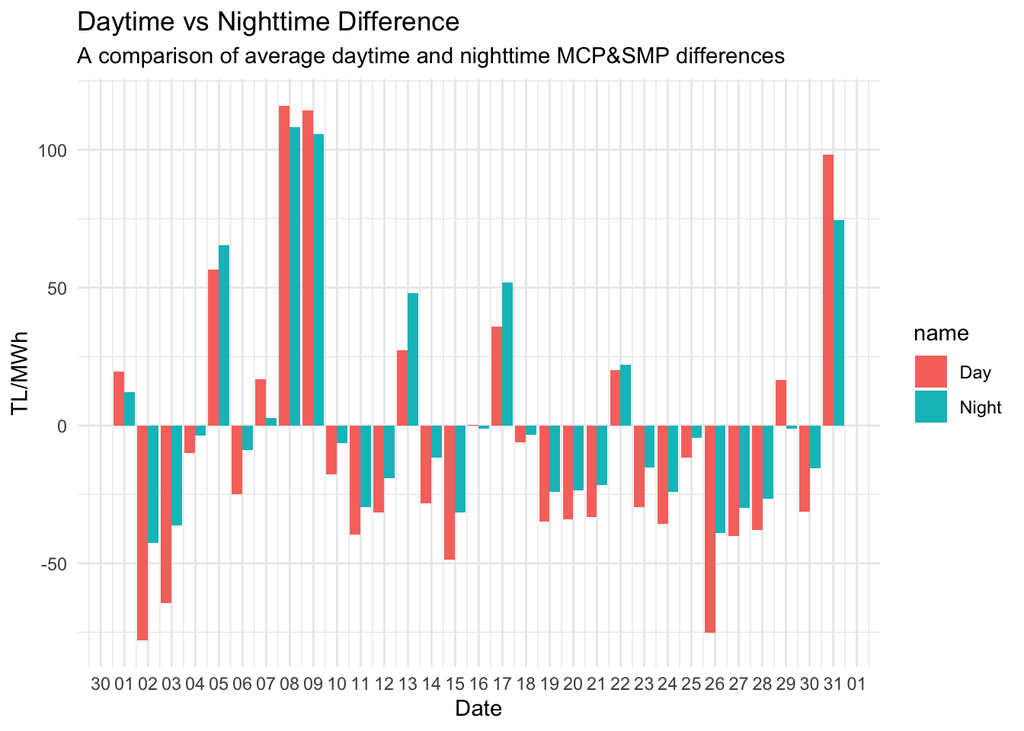

```r
#Daytime hours
daytime <- df %>%
  mutate(Hour=hour(DateTime),Day=as_date(DateTime)) %>%
  filter(Hour >= 8 & Hour <= 22) %>%
  select(Day,MCP, SMP) %>%
  group_by(Day) %>%
  summarise(MCP = mean(MCP), SMP = mean(SMP), DIFF = round(MCP-SMP,digits=2)) %>%
  arrange(DIFF)

#Nighttime hours
nighttime <- df %>%
  mutate(Hour=hour(DateTime),Night=as_date(DateTime)) %>%
  filter(Hour > 22 | Hour < 8) %>%
  select(Night,MCP, SMP) %>%
  group_by(Night) %>%
  summarise(MCP = mean(MCP), SMP = mean(SMP), DIFF = round(MCP-SMP,digits=2)) %>%
  arrange(DIFF)

daynight <- bind_cols(Date= daytime$Day, Day = daytime$DIFF, Night = nighttime$DIFF)

daynight %>% pivot_longer(.,-Date) %>% ggplot(aes(x=Date,y=value,fill=name)) +geom_bar(stat="identity", position ="dodge") + theme_minimal() + labs(x="Date", y="TL/MWh", color="", title = "Daytime vs Nighttime Difference ", subtitle = "A comparison of average daytime and nighttime MCP&SMP differences ") + scale_x_date(date_breaks = "1 day", date_labels = "%d")
```

Daily Average MCP during daytime is 307.004 and standard deviation is 21.17199 .

Daily Average MCP during nighttime is 278.6201 and standard deviation is 18.5382 .

Daily Average SMP during daytime is 313.1568 and standard deviation is 57.2093 .

Daily Average SMP during nighttime is 276.3158 and standard deviation is 42.72492 .

The ratio of MCP/SMP is also worth taking a look at:

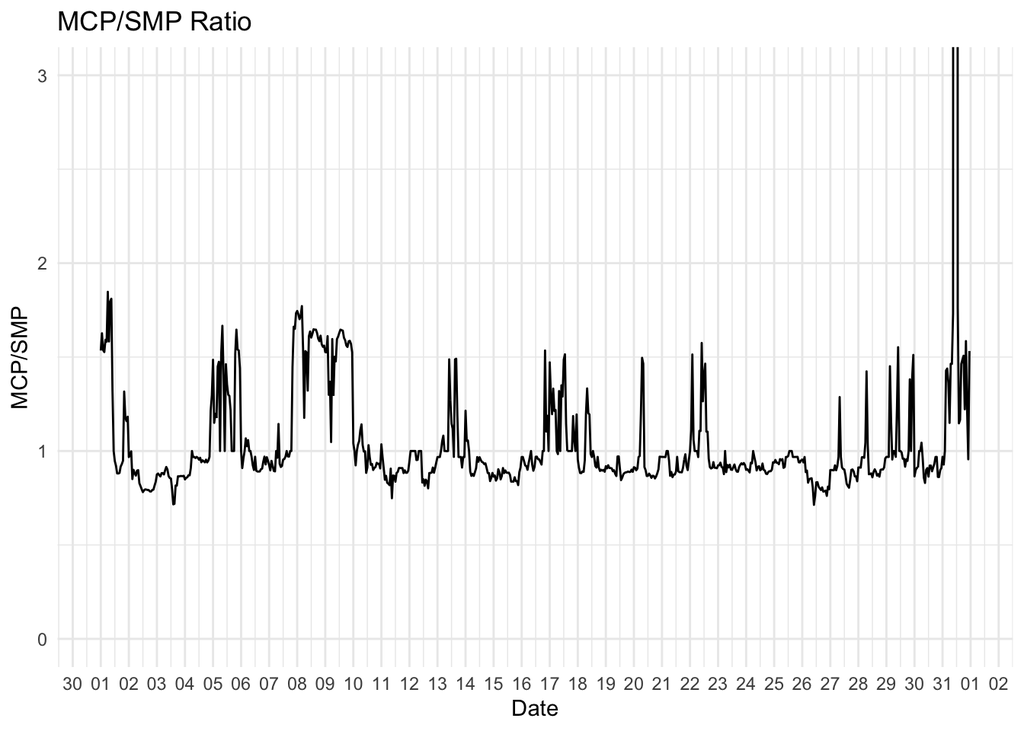

```r
#Lowest 10 MCP/SMP ratios
lowest <- df %>%
  mutate(MCP_SMP_RATIO = MCP/SMP) %>%
  select(DateTime,MCP_SMP_RATIO) %>%
  arrange(MCP_SMP_RATIO) %>%
  slice(1:10)

#Highest 10 MCP/SMP ratios
highest <- df %>%
  mutate(MCP_SMP_RATIO = MCP/SMP) %>%
  select(DateTime,MCP_SMP_RATIO) %>%
  arrange(desc(MCP_SMP_RATIO)) %>%
  slice(1:10)

df %>%
  mutate(MCP_SMP_RATIO = MCP/SMP) %>%
  select(DateTime,MCP_SMP_RATIO) %>%
  ggplot(aes(x=DateTime,y=MCP_SMP_RATIO)) +
  geom_line() +
  coord_cartesian(ylim = c(0, 3)) +
  scale_x_datetime(date_breaks = "1 day",date_labels = "%d") +
  labs(x="Date", y="MCP/SMP", color="", title = "MCP/SMP Ratio ") +
  theme_minimal()
```

Let’s take a look at which & how many hours the MCP is almost equal to SMP:

```r
almost <- df %>%
  mutate(roundMCP = round(MCP), roundSMP = round(SMP)) %>%
  filter(roundMCP == roundSMP) %>%
  select(DateTime, roundMCP,roundSMP) %>%
  rename(MCP = roundMCP, SMP = roundSMP)
print(almost)
```

```
## # A tibble: 65 x 3
##    DateTime              MCP   SMP
##    <dttm>              <dbl> <dbl>
##  1 2020-07-01 11:00:00   330   330
##  2 2020-07-04 06:00:00   238   238
##  3 2020-07-05 06:00:00   200   200
##  4 2020-07-05 10:00:00   200   200
##  5 2020-07-05 16:00:00   257   257
##  6 2020-07-05 17:00:00   211   211
##  7 2020-07-05 18:00:00   230   230
##  8 2020-07-06 00:00:00   234   234
##  9 2020-07-06 03:00:00   238   238
## 10 2020-07-06 07:00:00   194   194
## # … with 55 more rows
```

The percentage of hours MCP is almost equal to SMP (ratio is almost 1) is 8.74 %

```r
p <- df %>%
  filter(SMP < MCP)%>%
  count()/count(df)*100
```

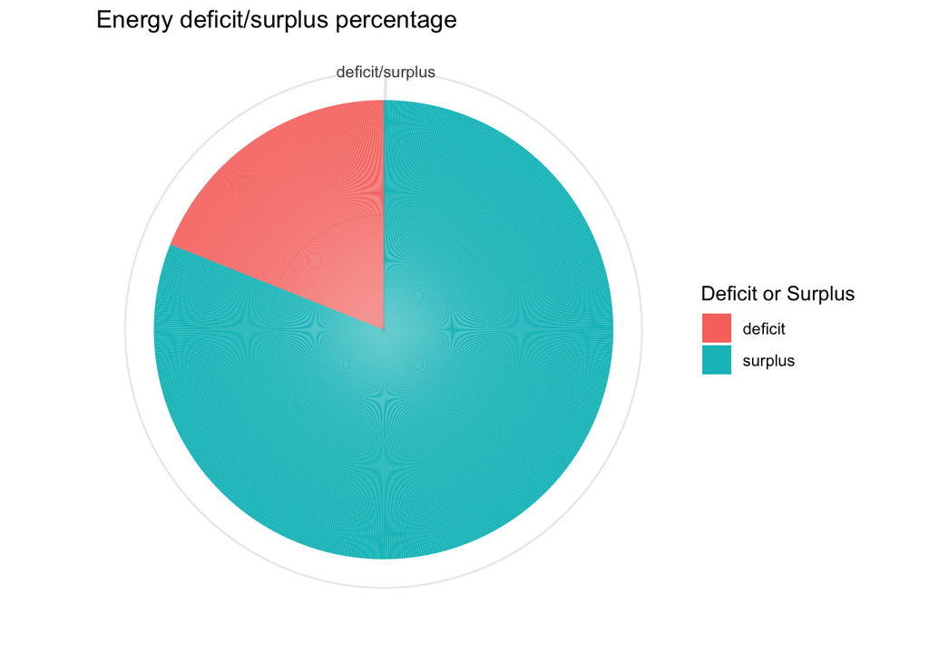

```r
df %>% mutate(SD = ifelse(SMP > MCP, "surplus", "deficit")) %>%
  ggplot(aes(x="",y=SD,fill=SD)) +
  geom_bar(stat="identity",width=1) +
  coord_polar("y", start = 0) +
  labs(title="Energy deficit/surplus percentage", x="",y="",fill = "Deficit or Surplus") +
  theme_minimal()
```

My progress journal can be reached from this [link](https://pjournal.github.io/boun01-egc-boun/).